# Reference Document

This notebook is used in order to go more in depth to many of the opencv functions used

[figure not shown]

```python
from google.colab.patches import cv2_imshow #Allows us to print images in google colab
import cv2 #importing opencv
import imutils #importing imutils
import numpy as np

image = image = cv2.imread('tetris_blocks.png') #Loading image
cv2_imshow(image) #showing image
```

### cvtColor()

- In order to convert from color spaces we use this functions
- It converts our current color space to a different
- All color space conversions in opencv can be found [here](https://docs.opencv.org/master/d8/d01/group__imgproc__color__conversions.html#ga4e0972be5de079fed4e3a10e24ef5ef0)

The reason here that we convert to grayscale is because we will be thresholding the image

[figure not shown]

[figure not shown]

```python
gray = cv2.cvtColor(image, cv2.COLOR_BGR2GRAY) #Here we convert from BGR to Gray
rgb = cv2.cvtColor(image, cv2.COLOR_BGR2RGB) #Here we convert from BGR to RGB

cv2_imshow(gray) #Show image
cv2_imshow(rgb)#Show image
```

### threshold()

Thresholding an image helps with segmentation. We change the pixels of an image to become binary, black or white. That way we can detect the objects in the image  
Lets take a look at the functions paramters  
cv2.threshold(image, threshold, maxVal, type_of_threshold)

- **Image:** This argument is the grayscale image you wish to use
- **threshold:** if pixel value is less than threshold it will be set to 0
- **maxVal:** any value is greater than the threshold it will be set to this maxVal
- **type_of_threshold:** set what kind of threshold [type](https://docs.opencv.org/master/d7/d4d/tutorial_py_thresholding.html) you want.

Since our image is simple we use simple thresholding techniques. The code we use for thresholding works well with our basic image but you'll need more sophisticated techniques for thresholding more complex images. The full threshold documentation can be found [here](https://docs.opencv.org/master/d7/d4d/tutorial_py_thresholding.html).

A couple things to notice from our code below

1. the threshold returns a tuple. That's why in our code we add a '[1]' at the end because we are only interested in the image which happens to be in the 1 index
2. We use the 'THRESH_BINARY_INV' type for our thresholding method. This inverts blacks and whites

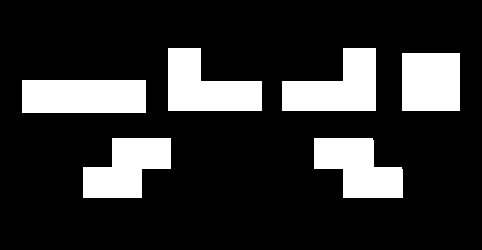

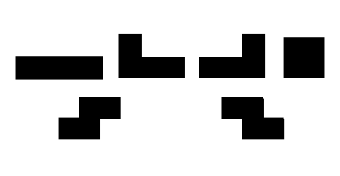

```
225.0
```

```python
thresh = cv2.threshold(gray, 225, 255, cv2.THRESH_BINARY_INV)[1] #accessing first item in tuple
cv2_imshow(thresh) #displays image
print(' ') #Adding space between images

ret, threshold = cv2.threshold(gray, 225, 255, cv2.THRESH_BINARY) #Assigning both elements in tuple
cv2_imshow(threshold)
print(ret)
```

### findCountours()

This function helps to find all the white pixels in the image so that we can highlight the objects  
Let's take a look at the function parameters:  
cv2.findContours(image, mode, method)

- **image:** thresholded image
- **mode:** Contour retrieval model. All modes listed [here](https://docs.opencv.org/3.4/d3/dc0/group__imgproc__shape.html#ga819779b9857cc2f8601e6526a3a5bc71)
- **Method:** Contour approximation method. All methods listed [here](https://docs.opencv.org/3.4/d3/dc0/group__imgproc__shape.html#ga4303f45752694956374734a03c54d5ff)

Let's take a look at the methods and modes we used for out image

- **RETR_EXTERNAL mode:** This mode retrieves extreme outer contours. We use this mode because we are detecting for the edges of a shape so this contour mode works perfectly for our application. You can find more information [here](https://docs.opencv.org/3.4/d9/d8b/tutorial_py_contours_hierarchy.html)
- **CHAIN_APPROX_SIMPLE method:** This method takes the contour and only saves the corners of each shape. That way we don't have all the edges stored but rather just the corners of the shapes. you can find more information [here](https://docs.opencv.org/trunk/d4/d73/tutorial_py_contours_begin.html)

```python
cnts = cv2.findContours(thresh.copy(), cv2.RETR_EXTERNAL, cv2.CHAIN_APPROX_SIMPLE)
print(cnts) #Prints detected corners from the 6 tetris pieces
```

```
([array([[[314, 138]],

       [[314, 168]],

       [[342, 168]],

       [[343, 169]],

       [[343, 197]],

       [[402, 197]],

       [[402, 169]],

       [[401, 168]],

       [[401, 167]],

       [[374, 167]],

       [[373, 166]],

       [[373, 140]],

       [[372, 139]],

       [[372, 138]]], dtype=int32), array([[[112, 138]],

       [[112, 166]],

       [[111, 167]],

       [[ 83, 167]],

       [[ 83, 197]],

       [[141, 197]],

       [[141, 169]],

```

[output cut: 31 more lines]

```

       [[261, 110]],

       [[261,  81]],

       [[201,  81]],

       [[200,  80]],

       [[200,  48]]], dtype=int32)], array([[[ 1, -1, -1, -1],
        [ 2,  0, -1, -1],
        [ 3,  1, -1, -1],
        [ 4,  2, -1, -1],
        [ 5,  3, -1, -1],
        [-1,  4, -1, -1]]], dtype=int32))
```

### grab_contours()

This imutils method helps with any issues we might encounter based on opencv version. You won't have to worry about this line it just detects your version and modifies the contour based on your version so opencv won't throw erros later. You can find the documentation [here](https://github.com/jrosebr1/imutils/blob/master/imutils/convenience.py#L154).

```python
cnts = imutils.grab_contours(cnts)
print(cnts)
```

```
[array([[[314, 138]],

       [[314, 168]],

       [[342, 168]],

       [[343, 169]],

       [[343, 197]],

       [[402, 197]],

       [[402, 169]],

       [[401, 168]],

       [[401, 167]],

       [[374, 167]],

       [[373, 166]],

       [[373, 140]],

       [[372, 139]],

       [[372, 138]]], dtype=int32), array([[[112, 138]],

       [[112, 166]],

       [[111, 167]],

       [[ 83, 167]],

       [[ 83, 197]],

       [[141, 197]],

       [[141, 169]],

```

[output cut: 26 more lines]

```
       [[375, 110]],

       [[375,  48]]], dtype=int32), array([[[168,  48]],

       [[168, 110]],

       [[261, 110]],

       [[261,  81]],

       [[201,  81]],

       [[200,  80]],

       [[200,  48]]], dtype=int32)]
```

### drawContours()

This functions is simple as it just draws the contour

[figure not shown]

```
[array([[[314, 138]],

       [[314, 168]],

       [[342, 168]],

       [[343, 169]],

       [[343, 197]],

       [[402, 197]],

       [[402, 169]],

       [[401, 168]],

       [[401, 167]],

       [[374, 167]],

       [[373, 166]],

       [[373, 140]],

       [[372, 139]],

       [[372, 138]]], dtype=int32)]
```

[figure not shown]

```
[array([[[112, 138]],

       [[112, 166]],

       [[111, 167]],

       [[ 83, 167]],

       [[ 83, 197]],

       [[141, 197]],

       [[141, 169]],

       [[142, 168]],

       [[170, 168]],

       [[170, 138]]], dtype=int32)]
```

[figure not shown]

```
[array([[[ 22,  80]],

       [[ 22, 112]],

       [[145, 112]],

       [[145,  80]]], dtype=int32)]
```

[figure not shown]

```
[array([[[402,  53]],

       [[402, 110]],

       [[459, 110]],

       [[459,  53]]], dtype=int32)]
```

[figure not shown]

```
[array([[[343,  48]],

       [[343,  80]],

       [[342,  81]],

       [[282,  81]],

       [[282, 110]],

       [[375, 110]],

       [[375,  48]]], dtype=int32)]
```

[figure not shown]

```
[array([[[168,  48]],

       [[168, 110]],

       [[261, 110]],

       [[261,  81]],

       [[201,  81]],

       [[200,  80]],

       [[200,  48]]], dtype=int32)]
```

```python
output = image.copy()

for c in cnts:
  #   drawContours(image, contour location, contour drawn, color, thickness)
  cv2.drawContours(output, [c], -1, (0,0,0), 3)
  cv2_imshow(output)
  print([c])
```